# L18

# Markov Models

- Want to reason about a sequence of observation
- Need to introduce time (or space) into our models and update beliefs based on
  - Getting more evidence (done with BNs)
  - World changing over time/space (Markov models)

## Probability Recap

- Conditional probability ≔ $\mathbb{P}(x|y)=\frac{\mathbb{P}(x,y)}{\mathbb{P}(y)}$
- Marginal probability ≔ $\mathbb{P}(x)=\sum_{y}\mathbb{P}(x,y)$
- Product rule ≔ $\mathbb{P}(x,y)=\mathbb{P}(x|y)\mathbb{P}(y)$
- Chain rule ≔ $\mathbb{P}(X_{1},X_{2},X_{n})=\prod_{i=1}^{n}\mathbb{P}(X_{i}|X_{1},{\dots}X_{i-1})$
- $X$ independent with $Y$ ⟺ $\forall{x,y}:\mathbb{P}(x,y)=\mathbb{P}(x)\mathbb{P}(y)$
- $X$ and $Y$ conditionally independent given $Z$ ⟺ $\forall{x,y,z}:\mathbb{P}(x,y|z)=\mathbb{P}(x|z)\mathbb{P}(y|z)$
  - Basically independent, but tagging on given $z$ to every probability function
- Proportionality ≙ $\left.\mathbb{P}(X)\propto_{x}{f(X)}\iff{\mathbb{P}(X)=kf(X)}\right\vert_{k\coloneqq{\text{constant not dependent on x}}}$
  - Equivalent to $\mathbb{P}(X)=\frac{f(X)}{\sum_{x}f(x)}$

## Markov Chains

- How beliefs about state change with passage of time
- The value of $X$ at a given time is called the state
  - Each $X$ includes the full distribution over all possible states

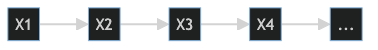

- Parameter ≔ transition probabilities or dynamics; specify how the state evolves over time (also, initial state probabilities)
  - Initial state probabilities ≔ $\mathbb{P}(X_{1})$
  - Transition probabilities ≔ $\mathbb{P}(X_{t}|X_{t-1})$
- Stationary assumption ≔ transition probabilities are the same at all times
  - $\mathbb{P}(X_{1}|X_{0})=\mathbb{P}(X_{2}|X_{1})$
  - The directed edges are the same probability for all transitions
- Same as MDP transition model, but with no choice of action
- A ‘growable’ BN (can always use BN methods if we truncate to fixed length)
- Past and future are independent given the present
  - Each time step only depends on the previous
  - Called the (first order) Markov property
- eg:

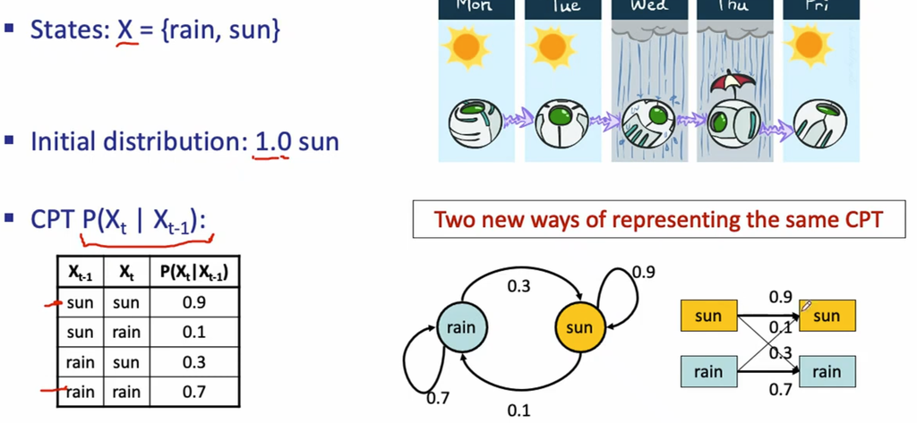

  - $\mathbb{P}(X_{2}=\text{sun})=\sum_{x_{1}}\mathbb{P}(x_{1},X_{2}=\text{sun})=\sum_{x_{1}}\mathbb{P}(X_{2}=\text{sun}|x_{1})\mathbb{P}(x_{1})$

### Mini-Forward Algorithm

- Given $\mathbb{P}(X_{1})$ and $\mathbb{P}(X_{t}|X_{t-1})$
- Alg: $\mathbb{P}(x_{t})=\sum_{x_{t-1}}\mathbb{P}(x_{t-1},x_{t})=\sum_{x_{t-1}}\mathbb{P}(x_{t}|x_{t-1})\mathbb{P}(x_{t-1})$
  - Have to build up $\mathbb{P}(x_{t-1})$ recursively
- Converges to some fixed (stationary) distribution
  - Same when extended for any arbitrary state in the simulation
  - Starting state does not matter

### Stationary Distributions

- Distribution converges
- Denoted with $\mathbb{P}_{{\infty}}$
- $\mathbb{P}_{{\infty}}(X)=\mathbb{P}_{{\infty}+1}(X)=\sum_{x}\mathbb{P}(X|x)P_{{\infty}}(x)$
- Note that the sum of all probabilities at their stationary distribution sum to 1
  - Can give an extra equation if needed

## Hidden Markov Models (HMMs) formulation

- How beliefs change with passage of time and evidence
- Underlying Markov chain over states $X$
- You observe outputs (effects) at each time step
- Effects / emissions at each step ≔ $\mathbb{P}(E_{t}|X_{t})$
  - Just another table like the transition table given the state
- Have two important independence properties
  1. Markov hidden process ≙ future depends on past via the present
  2. Current observation independent of all else given current state
- Evidence variables are not necessarily independent (need some given state between them to make them independent)

## Filtering with HMMs

- How to infer beliefs from evidence
- Belief state ≔ $B_{t}(X)=\mathbb{P}_{t}(X_{t}|e_{1},{\dots},e_{t})$
  - Belief of $X$ at time $t$
- Start with a guess $B_{1}(X)$ (usually uniform)
  - Update with more evidence gained over time
- Idea: start with $\mathbb{P}(X_{1})$ and try to derive $B_{t}$ in terms of $B_{t-1}$
  - $\mathbb{P}(X_{t+1}|e_{1:t})=\sum_{x_{t}}\mathbb{P}(X_{t+1},x_{t}|e_{1:t})=\sum_{x_{t}}\mathbb{P}(X_{t+1},x_{t}|e_{1:t})\mathbb{P}(x_{t}|e_{1:t})$
    - The final factor of the last equation is the previous belief
    - Can ignore the evidence in the first half of the summation yielding $\sum_{x_{t}}\mathbb{P}(X_{t+1}|x_{t})\mathbb{P}(x_{t}|e_{1:t})$
  - $B'(X_{t+1})=\sum_{x_{t}}\mathbb{P}(X'|x_{t})B(x_{t})$
  - Beliefs get ‘pushed’ through the transitions